# Chapter8

Amanda P

2/3/2018

# 8.2.1 Exercises

1. Try out all the themes in ggthemes. Which do you like the best?

```r
install.packages("ggthemes")
library(ggthemes)
```

2. What aspects of the default theme do you like? What don’t you like? What would you change?

First define base graphic:

```r
df <- data.frame(x=1:3, y=1:3)
base <- ggplot(df, aes(x,y)) + geom_point()
```

The following themes are from the `ggtheme` package and not already shown in the book.

- theme_base: a theme resembling the default base graphics in R. See also theme_par.

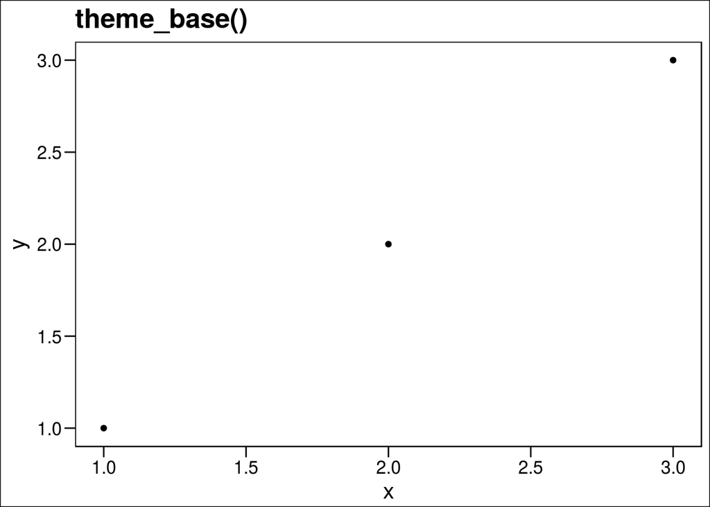

```r
base + theme_base() + ggtitle("theme_base()")
```

- theme_calc: a theme based on LibreOffice Calc.

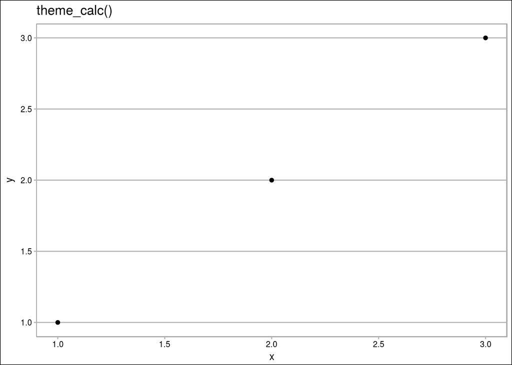

```r
base + theme_calc() + ggtitle("theme_calc()")
```

- theme_economist: a theme based on the plots in the The Economist magazine.

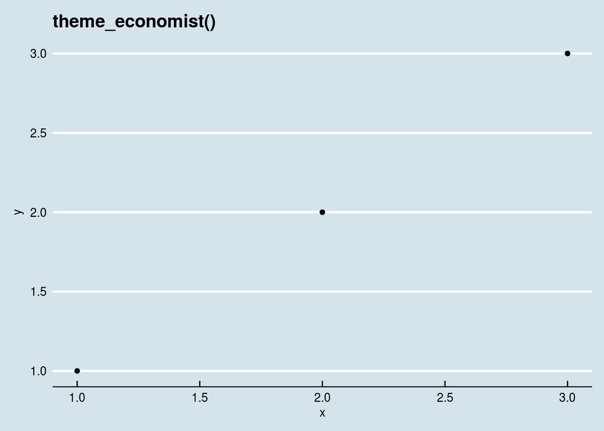

```r
base + theme_economist() + ggtitle("theme_economist()")
```

- theme_few: theme from Stephen Few’s “Practical Rules for Using Color in Charts”.

[figure not shown]

```r
base + theme_few() + ggtitle("theme_few()")
```

- theme_fivethirtyeight: a theme based on the plots at fivethirtyeight.com.

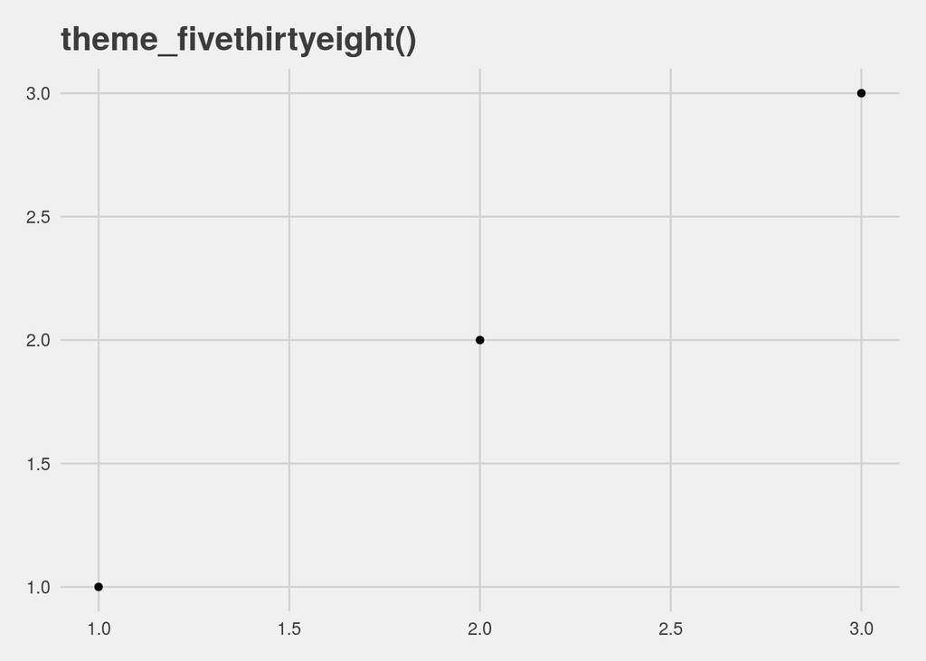

```r
base + theme_fivethirtyeight() + ggtitle("theme_fivethirtyeight()")
```

- theme_gdocs: a theme based on Google Docs.

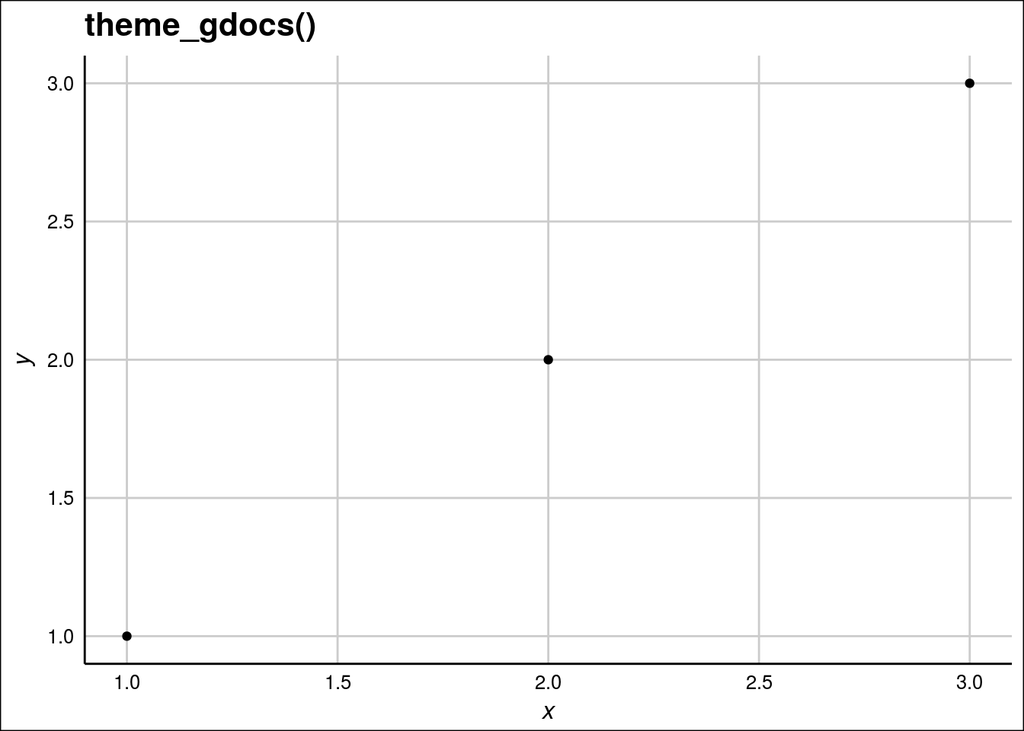

```r
base + theme_gdocs() + ggtitle("theme_gdocs()")
```

theme_hc: a theme based on Highcharts JS.

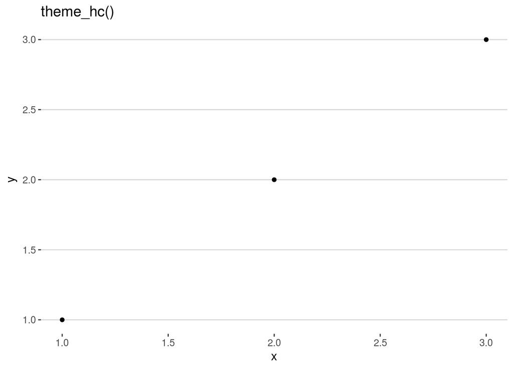

```r
base + theme_hc() + ggtitle("theme_hc()")
```

- theme_par: a theme that uses the current values of the base graphics parameters in par.

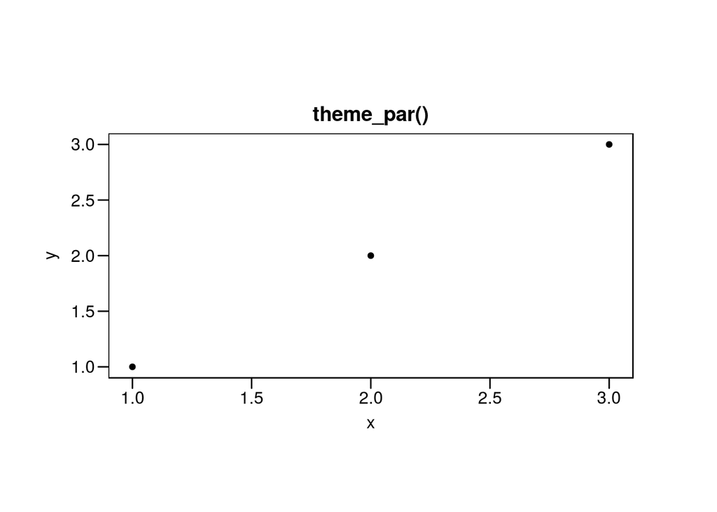

```r
base + theme_par() + ggtitle("theme_par()")
```

- theme_pander: a theme to use with the pander package.

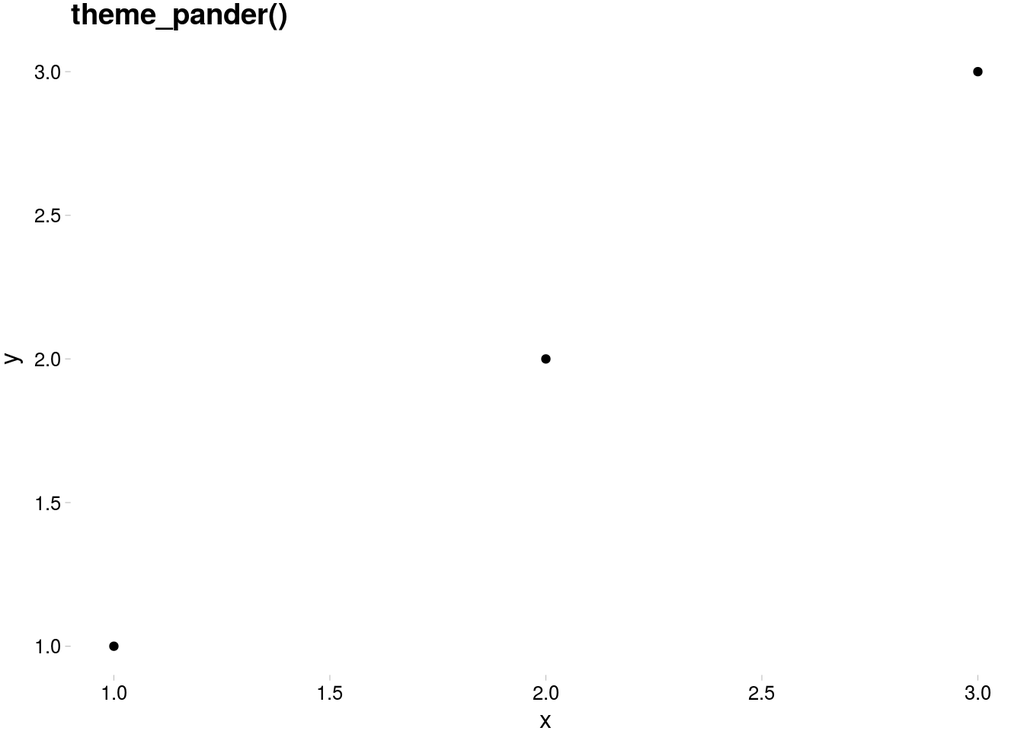

```r
base + theme_pander() + ggtitle("theme_pander()")
```

- theme_stata: themes based on Stata graph schemes.

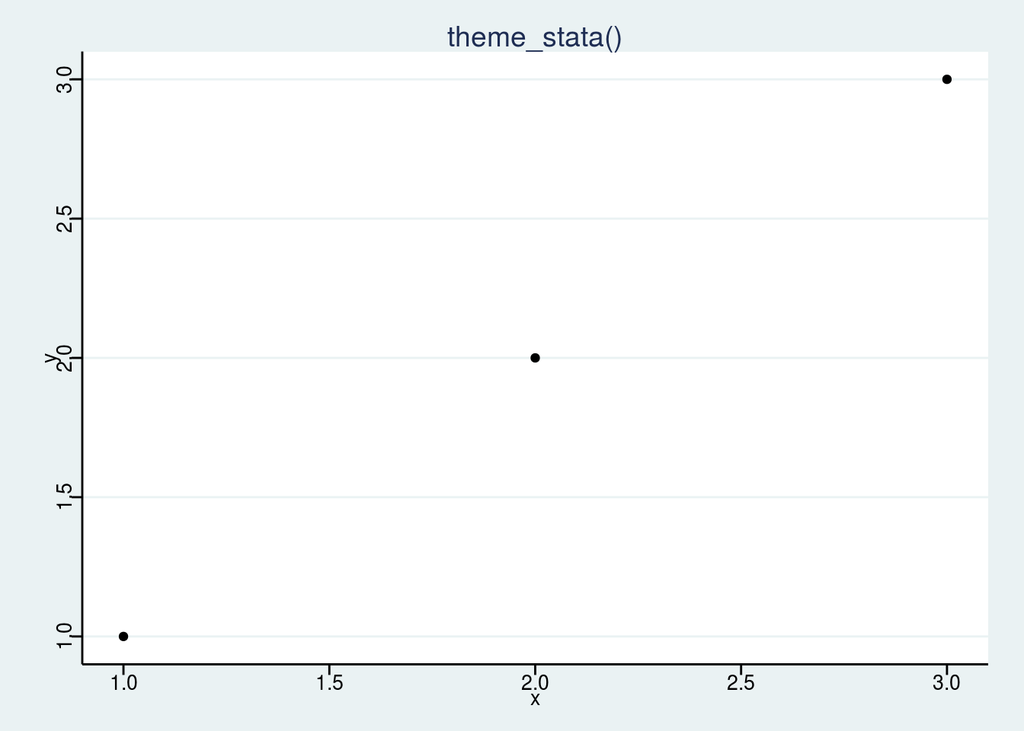

```r
base + theme_stata() + ggtitle("theme_stata()")
```

- theme_wsj: a theme based on the plots in the The Wall Street Journal.

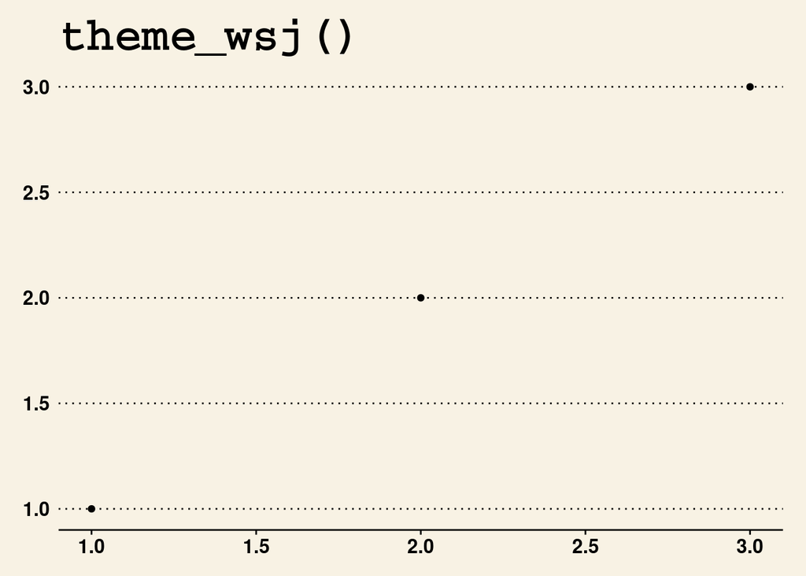

```r
base + theme_wsj() + ggtitle("theme_wsj()")
```

3. Look at the plots in your favorite scientific journal. What themes do they most resemble? What are the main differences?

Looking at the April 2018 issue of Significance Magazine, plots most resemble the following themes: * theme_par * theme_grey, however, axis tickmarks are not used

# 8.4.6 Exercises

1. Create the ugliest plot possible! (Contributed by Andrew D. Steen, University of Tenessee - Knoxville)

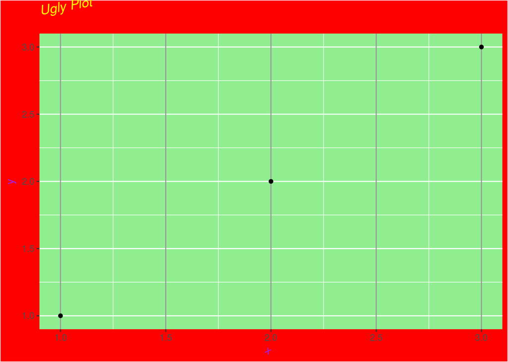

```r
base + ggtitle("Ugly Plot") + theme(plot.background = element_rect(fill="red"),panel.background = element_rect(fill="lightgreen"),panel.grid.major.x = element_line(color="gray60"),plot.title= element_text(face="italic",color="yellow",angle = 10),axis.title = element_text(color="purple", angle = -30 ))
```

2. `theme_dark()` makes the inside of the plot dark, but not the outside. Change the plot background to black, and then update the text settings so you can still read the labels.

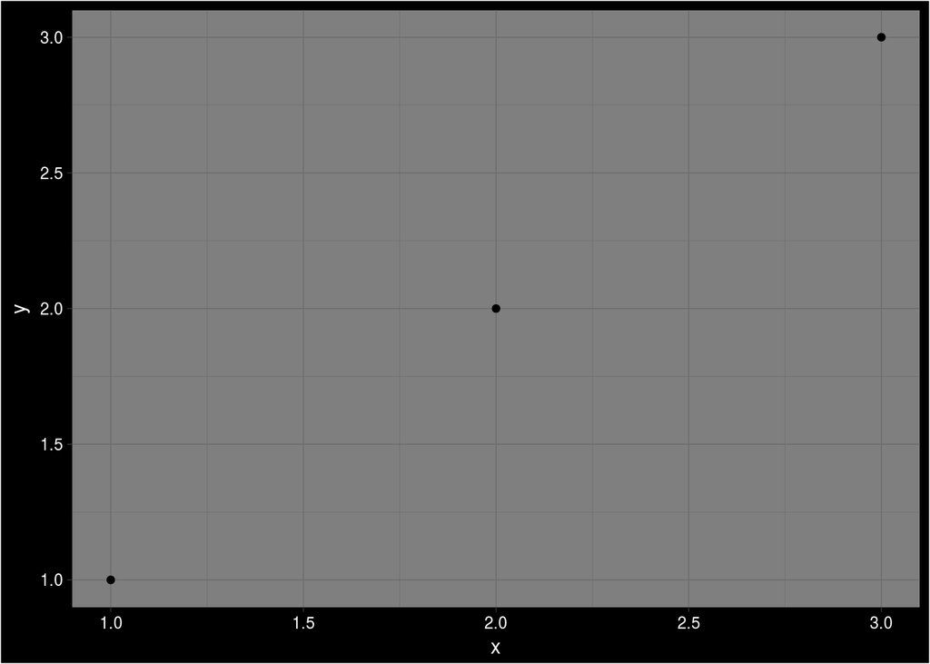

```r
base + theme_dark() + theme(plot.background = element_rect(fill="black"),axis.text = element_text(color="white"),axis.title = element_text(color="white"))
```

3. Make an elegant theme that uses “linen” as the background color and a serif font for the text.

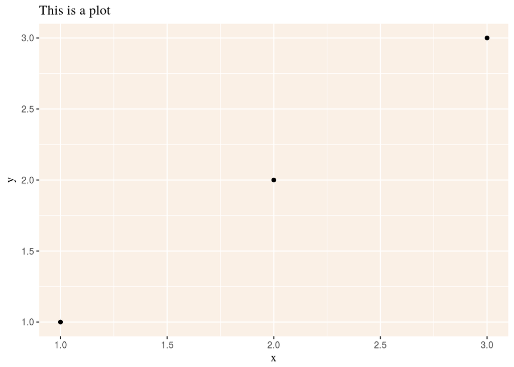

```r
base + ggtitle("This is a plot") + theme(panel.background = element_rect(fill="linen"),plot.title= element_text(family="serif"),axis.title = element_text(family="serif"))
```

4. Systematically explore the effects of `hjust` when you have a multiline title. Why doesn’t `vjust` do anything?

Left justified:

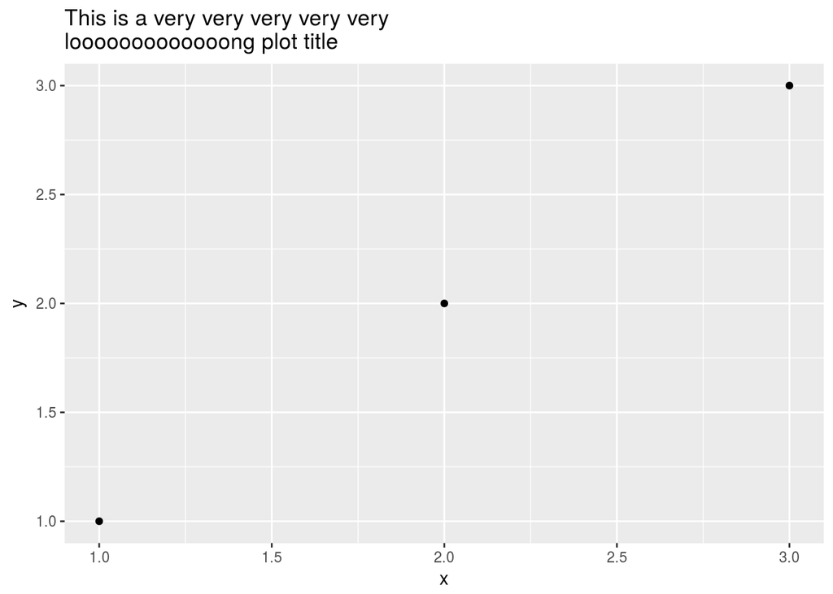

```r
base + ggtitle("This is a very very very very very\nlooooooooooooong plot title") + theme(plot.title = element_text(hjust=0))
```

Centered:

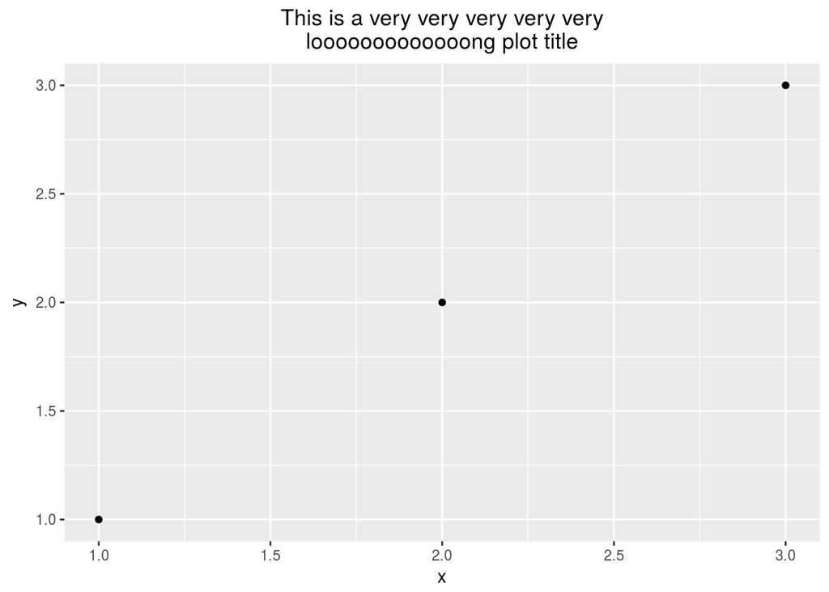

```r
base + ggtitle("This is a very very very very very\nlooooooooooooong plot title") + theme(plot.title = element_text(hjust=.5))
```

Right justified:

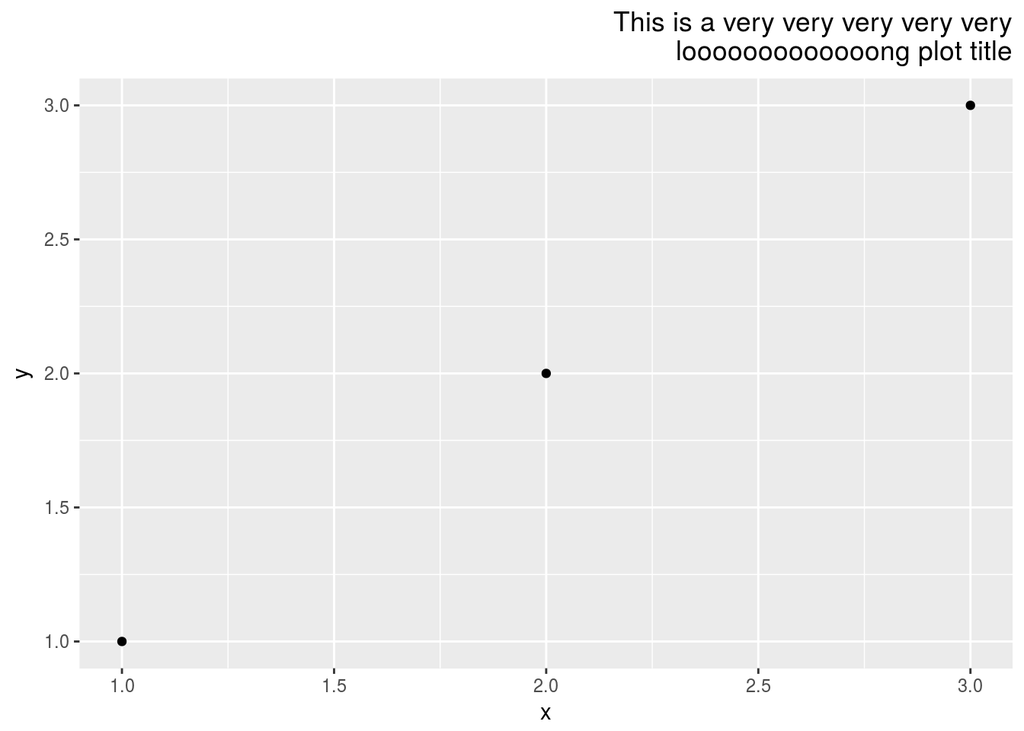

```r
base + ggtitle("This is a very very very very very\nlooooooooooooong plot title") + theme(plot.title = element_text(hjust=1))
```

Printed over the edge of the plot:

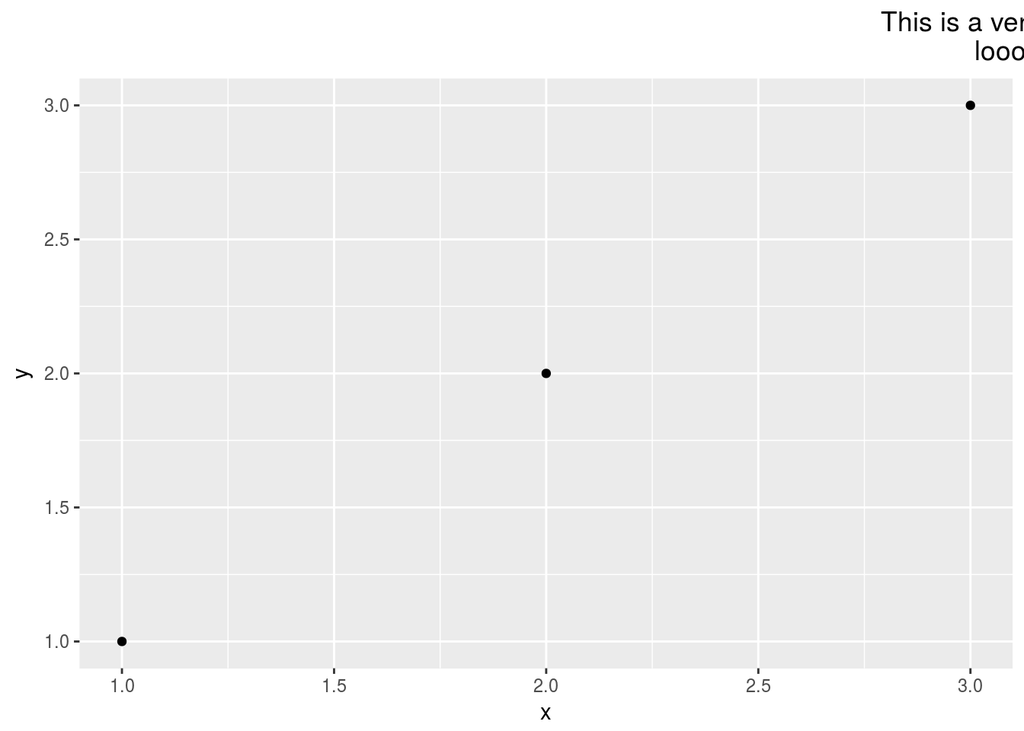

```r
base + ggtitle("This is a very very very very very\nlooooooooooooong plot title") + theme(plot.title = element_text(hjust=1.5))
```

The last part of the question is “Why doesn’t vjust do anything?” It seems that `vjust` moves the text vertically (slightly).

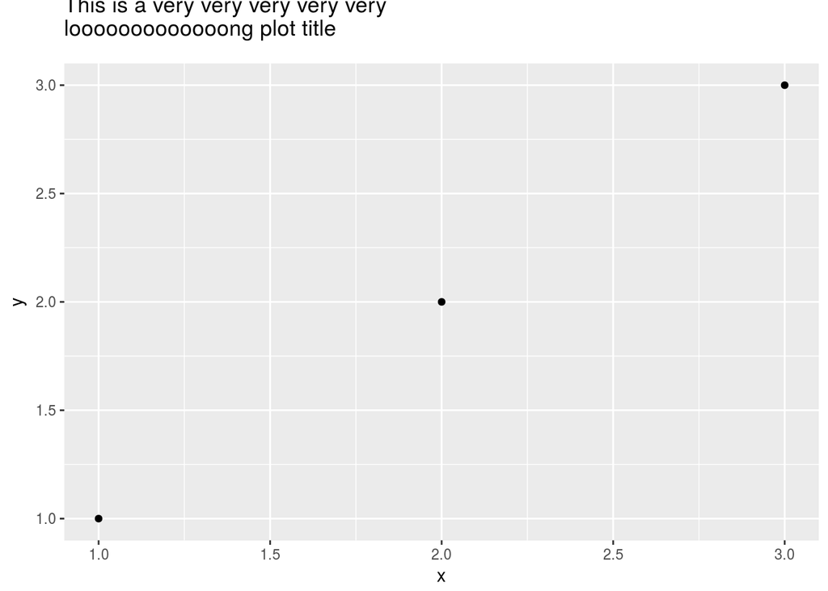

```r
base + ggtitle("This is a very very very very very\nlooooooooooooong plot title") + theme(plot.title = element_text(vjust=4))
```